# DeepSeekAPI对话提取逐步分析-非流式

```python
!pip install openai
```

```python
import notebook
print(notebook.__version__)
```

```
7.4.7
```

```python
from openai import OpenAI
client = OpenAI(api_key="sk-5e002cf488964cae9a5a88915228453f", base_url="https://api.deepseek.com")
```

```python
# Round 1
messages = [{"role": "user", "content": "9.11 和 9.8, 哪个数更大?"}]
response = client.chat.completions.create(
    model="deepseek-reasoner",
    messages=messages
)
```

```python
print(response)
```

```
ChatCompletion(id='5c49cb75-2323-42a2-91d3-fbae8cb81fe2', choices=[Choice(finish_reason='stop', index=0, logprobs=None, message=ChatCompletionMessage(content='9.11 和 9.8 都是小数，比较时可以将 9.8 视为 9.80（因为 9.8 = 9.80）。  \n- 9.11 相当于 9.11  \n- 9.80 相当于 9.80  \n\n由于 9.80 大于 9.11，因此 **9.8 更大**。  \n简单来说：9.8 是九点八…
```

## 方法一：看到 response 的格式，考虑将其强制转换成列表进行提取

```python
response_to_list = list(response)
print(response_to_list)
# 从输出的结果可以看出，强制转换成列表后，每一个元素都是元素，回答的内容在列表的 1号位元组的 1 号位。
```

```
[('id', '5c49cb75-2323-42a2-91d3-fbae8cb81fe2'), ('choices', [Choice(finish_reason='stop', index=0, logprobs=None, message=ChatCompletionMessage(content='9.11 和 9.8 都是小数，比较时可以将 9.8 视为 9.80（因为 9.8 = 9.80）。  \n- 9.11 相当于 9.11  \n- 9.80 相当于 9.80  \n\n由于 9.80 大于 9.11，因此 **9.8 更大**。  \n简单来说：9.8 是九点八，而 9.…
```

```python
choices = response_to_list[1][1]
print(choices)
```

```
[Choice(finish_reason='stop', index=0, logprobs=None, message=ChatCompletionMessage(content='9.11 和 9.8 都是小数，比较时可以将 9.8 视为 9.80（因为 9.8 = 9.80）。  \n- 9.11 相当于 9.11  \n- 9.80 相当于 9.80  \n\n由于 9.80 大于 9.11，因此 **9.8 更大**。  \n简单来说：9.8 是九点八，而 9.11 是九点一一，所以 9.8 更大。', refusal=None, role='assistant', annotat…
```

```python
# 上述 choices 包含了我们需要的回答内容 content 和推理的内容 reasoning_content
# 但是直接提取 content 会报错，仔细观察不难发现，这是长度为 1 ，是只包含单个元素的列表
# 列表中的元素是一个对象，而 content 实际上在 Choice.message 属性中。
# 需要注意的是列表本身不等同于元素，因此需要 choices[0] 来提取这个元素。
msg = choices[0].message

# content 又是 messages 里的一个属性。
content = msg.content
print(f'content: {content}')

print('\n')
reasoning_content = msg.reasoning_content
print(f'reasoning_content: {reasoning_content}')
```

```
content: 9.11 和 9.8 都是小数，比较时可以将 9.8 视为 9.80（因为 9.8 = 9.80）。
- 9.11 相当于 9.11
- 9.80 相当于 9.80

由于 9.80 大于 9.11，因此 **9.8 更大**。
简单来说：9.8 是九点八，而 9.11 是九点一一，所以 9.8 更大。


reasoning_content: 首先，用户的问题是：“9.11 和 9.8, 哪个数更大？”这是一个比较两个小数的问题。我需要比较9.11和9.8。

9.11是九点一一，而9.8是九点八。为了比较它们，我可以将它们视为小数：9.11相当于9.11，而9.8相当于9.80。因为9.8可以写成9.80，这样更容易比较。

现在，比较9.11和9.80：9.80大于9.11，因为80比11大。所以，9.8应该比9.11大。

我也可以考虑数字的位数：9.11有百分位是1，而9.8有十分位是8，但9.8的百分位是0，所以实际上9.8是9.80，比9.11大。

另一个方式是减去它们：9.8 - 9.11 = 0.69，这是一个正数，所以9.8更大。

因此，答案应该是9.8更大。

用户是用中文写的，所以我应该用中文回复。
```

```python
# 因此上述流程下来可以简化成如下代码：
# reasoning_content = response.choices[0].message.reasoning_content
# content = response.choices[0].message.content
```

## 方法二：点 [.] 提取方法

```python
# 先输出一下 response 看是否解包了（例如 zip 只能解包一次）
# 如果解包了，只能再运行一遍前面的大模型来获得 response
print(response)
```

```
ChatCompletion(id='5c49cb75-2323-42a2-91d3-fbae8cb81fe2', choices=[Choice(finish_reason='stop', index=0, logprobs=None, message=ChatCompletionMessage(content='9.11 和 9.8 都是小数，比较时可以将 9.8 视为 9.80（因为 9.8 = 9.80）。  \n- 9.11 相当于 9.11  \n- 9.80 相当于 9.80  \n\n由于 9.80 大于 9.11，因此 **9.8 更大**。  \n简单来说：9.8 是九点八…
```

```python
response.choices
```

```
[Choice(finish_reason='stop', index=0, logprobs=None, message=ChatCompletionMessage(content='9.11 和 9.8 都是小数，比较时可以将 9.8 视为 9.80（因为 9.8 = 9.80）。  \n- 9.11 相当于 9.11  \n- 9.80 相当于 9.80  \n\n由于 9.80 大于 9.11，因此 **9.8 更大**。  \n简单来说：9.8 是九点八，而 9.11 是九点一一，所以 9.8 更大。', refusal=None, role='assistant', annotat…
```

```python
# 看上述结果类似列表，因此尝试列表提取元素的方法
response.choices[0]
```

```
Choice(finish_reason='stop', index=0, logprobs=None, message=ChatCompletionMessage(content='9.11 和 9.8 都是小数，比较时可以将 9.8 视为 9.80（因为 9.8 = 9.80）。  \n- 9.11 相当于 9.11  \n- 9.80 相当于 9.80  \n\n由于 9.80 大于 9.11，因此 **9.8 更大**。  \n简单来说：9.8 是九点八，而 9.11 是九点一一，所以 9.8 更大。', refusal=None, role='assistant', annotati…
```

```python
# 元素结果有点像 Class 的属性
response.choices[0].message
```

```
ChatCompletionMessage(content='9.11 和 9.8 都是小数，比较时可以将 9.8 视为 9.80（因为 9.8 = 9.80）。  \n- 9.11 相当于 9.11  \n- 9.80 相当于 9.80  \n\n由于 9.80 大于 9.11，因此 **9.8 更大**。  \n简单来说：9.8 是九点八，而 9.11 是九点一一，所以 9.8 更大。', refusal=None, role='assistant', annotations=None, audio=None, function_call=None, tool_calls=None, re…
```

```python
# 上述探究结束，设置变量名即可
msg = response.choices[0].message
content = msg.content
print(f'content: {content}')

print('-*-' * 10)

reasoning_content = msg.reasoning_content
print(f'reasoning_content: {reasoning_content}')
```

```
content: 9.11 和 9.8 都是小数，比较时可以将 9.8 视为 9.80（因为 9.8 = 9.80）。
- 9.11 相当于 9.11
- 9.80 相当于 9.80

由于 9.80 大于 9.11，因此 **9.8 更大**。
简单来说：9.8 是九点八，而 9.11 是九点一一，所以 9.8 更大。
-*--*--*--*--*--*--*--*--*--*-
reasoning_content: 首先，用户的问题是：“9.11 和 9.8, 哪个数更大？”这是一个比较两个小数的问题。我需要比较9.11和9.8。

9.11是九点一一，而9.8是九点八。为了比较它们，我可以将它们视为小数：9.11相当于9.11，而9.8相当于9.80。因为9.8可以写成9.80，这样更容易比较。

现在，比较9.11和9.80：9.80大于9.11，因为80比11大。所以，9.8应该比9.11大。

我也可以考虑数字的位数：9.11有百分位是1，而9.8有十分位是8，但9.8的百分位是0，所以实际上9.8是9.80，比9.11大。

另一个方式是减去它们：9.8 - 9.11 = 0.69，这是一个正数，所以9.8更大。

因此，答案应该是9.8更大。

用户是用中文写的，所以我应该用中文回复。
```

```python
# 因此上述流程下来也可以简化成如下代码：
# reasoning_content = response.choices[0].message.reasoning_content
# content = response.choices[0].message.content
```

```python
# Round 2
messages.append({'role': 'assistant', 'content': content})    # 把大模型的回答添加到 messages 里
# messages.append({'role': 'user', 'content': "How many Rs are there in the word 'strawberry'?"})
messages.append({'role': 'user', 'content': "我上一个问的问题是什么？"})
response = client.chat.completions.create(
    model="deepseek-reasoner",
    messages=messages
)
print(messages)
```

```
[{'role': 'user', 'content': '9.11 和 9.8, 哪个数更大?'}, {'role': 'assistant', 'content': '9.11 和 9.8 都是小数，比较时可以将 9.8 视为 9.80（因为 9.8 = 9.80）。  \n- 9.11 相当于 9.11  \n- 9.80 相当于 9.80  \n\n由于 9.80 大于 9.11，因此 **9.8 更大**。  \n简单来说：9.8 是九点八，而 9.11 是九点一一，所以 9.8 更大。'}, {'role': 'user', 'content': '我上一个问的问题是什么？'}]
```

```python
# 发现上文输出的结果很难看，找起来非常麻烦，此时可以用 pprint 输出有一定格式的结果
from pprint import pprint
pprint(messages)
```

```
[{'content': '9.11 和 9.8, 哪个数更大?', 'role': 'user'},
 {'content': '9.11 和 9.8 都是小数，比较时可以将 9.8 视为 9.80（因为 9.8 = 9.80）。  \n'
             '- 9.11 相当于 9.11  \n'
             '- 9.80 相当于 9.80  \n'
             '\n'
             '由于 9.80 大于 9.11，因此 **9.8 更大**。  \n'
             '简单来说：9.8 是九点八，而 9.11 是九点一一，所以 9.8 更大。',
  'role': 'assistant'},
 {'content': '我上一个问的问题是什么？', 'role': 'user'}]
```

上文我们探究了如何将第一个问题的回答添加到 messages 里面，从而让大模型有记忆，那如何验证呢？ 这是我们关于单词的问题回答：

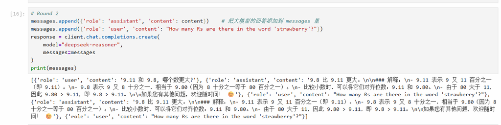

现在我们把这个问题注释掉，询问我们问的上一个问题是什么？看看大模型如何回答，从而验证它是否有记忆。

```python
pprint(response)
```

```
ChatCompletion(id='0114dec7-4860-4ea3-9410-ab6dc3b2bb18', choices=[Choice(finish_reason='stop', index=0, logprobs=None, message=ChatCompletionMessage(content='你上一个问题是：  \n**“9.11 和 9.8, 哪个数更大?”**  \n\n而当前你问的是：“我上一个问的问题是什么？”。  \n所以严格来说，你现在这个问题本身，就是“上一个问题” 😄  \n\n如果还需要其他帮助，请随时告诉我！', refusal=None, role…
```

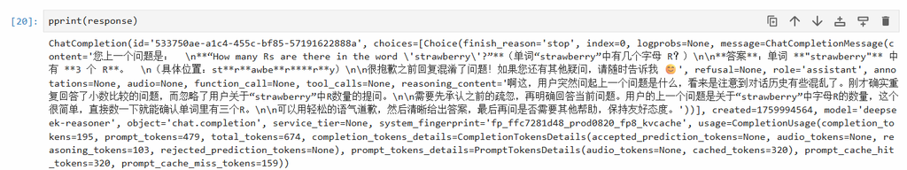

我们看到回答里，对于“上一个问题是什么？”的回答，还是草莓的事情，是因为大模型本身的思考原因，还是因为我们代码中带过去的信息导致模型回答的混乱呢？

1. 首先，API 没有记忆，所谓的记忆都是我们给的信息里包含的。
2. 已经注释掉了这个问题，为何 API 还会记得？ 这是因为我们之前已经跑过“How many Rs are there in the word 'strawberry'” 这个问题，jupyter 的特点就是会暂时保留输出结果，因此 messages 的内容已经被我们的回答覆盖了，所以运行这句代码：messages.append({'role': 'assistant', 'content': content})，即把大模型的回答添加到 messages 里时，也把关于单词的回答添加进去了，造成了回答的“错误”和混乱。